# Análisis y procesado de los datos

### 4. Atributos numéricos + categóricos One Hot Encoding + Robust Scaler + Polinomial Gridsearch + new atribute

```python
from sklearn.preprocessing import RobustScaler
```

```python
best_models = {"with_reg": None, "without_reg": None}
for b in best_models.keys():
    if b == "with_reg":
        logistic_grid_values = {
                 'classifier__penalty': ['l2'],
                 'classifier__C': [0.0001, 0.001,0.01]
        }
    else:
        logistic_grid_values = {
                 'classifier__penalty': ['none']
        }

    numerical_grid_values = {'preprocess__preprocessor__num__poly_features__degree': [1, 2, 3]}


    numerical_transformer = Pipeline([
            ("poly_features", PolynomialFeatures(interaction_only=True)),
            ('scaler', RobustScaler()),
        ])

    print(b)
    poly_best_cv = define_pipeline_and_optimize(
                                                numerical_pipeline=numerical_transformer,
                                                model_grid_values=logistic_grid_values,
                                                custom_grid_values=numerical_grid_values,
                                                model=LogisticRegression(random_state=42, max_iter=1000))
    best_models[b] = poly_best_cv
    print()
```

```
with_reg
{'classifier__C': 0.01, 'classifier__penalty': 'l2', 'preprocess__preprocessor__num__poly_features__degree': 2}
accuracy: 0.57
precision: 0.59
recall: 0.76
f1: 0.66

without_reg
{'classifier__penalty': 'none', 'preprocess__preprocessor__num__poly_features__degree': 1}
accuracy: 0.58
precision: 0.59
recall: 0.75
f1: 0.66
```

```
with_reg
```

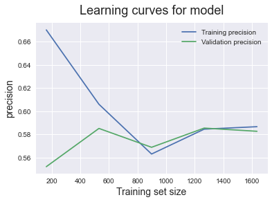

```
without_reg
```

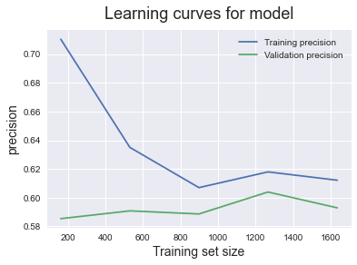

```python
for k,v in best_models.items():
    print(k)
    plot_learning_curves(v, train_X, train_y)
    v.fit(train_X, train_y)
    print()
```

```python
poly_best_robust_cv = best_models["with_reg"]
```

### 5. Atributos numéricos + categóricos One Hot Encoding + new atribute + log/square root

Probar log y square root sin loudness (es negativo)

```python
class CustomTransformer(BaseEstimator, TransformerMixin):
    """Takes in dataframe and creates new features """

    def __init__(self, log=False, exclude=None):
        self.log = log
        self.square_root = (log == False)
        self.exclude = exclude # exclude the variable with negative values

    def fit(self, X, y=None):
        return self

    def transform(self, X, y=None):
        new = X.copy()
        if self.exclude:
            new.drop(self.exclude, axis=1, inplace=True)

        method = None

        if self.log is True:
            method = np.log1p
        elif self.square_root is True:
            method = np.sqrt
        if method:
            for c in new.columns:
                new[c] = method(new[c])
        return new
```

```python
best_models = {"with_reg": None, "without_reg": None}
for b in best_models.keys():
    if b == "with_reg":
        logistic_grid_values = {
                 'classifier__penalty': ['l2'],
                 'classifier__C': [0.0001, 0.001,0.01]
        }
    else:
        logistic_grid_values = {
                 'classifier__penalty': ['none']
        }

    numerical_transformer = Pipeline([
            ("custom_transformations", CustomTransformer(exclude="loudness")) ])

    numerical_grid_values = {'preprocess__preprocessor__num__custom_transformations__log': [True, False]}

    print(b)

    log_best = define_pipeline_and_optimize(
                                                numerical_pipeline=numerical_transformer,
                                                model_grid_values=logistic_grid_values,
                                                custom_grid_values=numerical_grid_values,
                                                model=LogisticRegression(random_state=42))

    best_models[b] = log_best
    print()
```

```
with_reg
{'classifier__C': 0.01, 'classifier__penalty': 'l2', 'preprocess__preprocessor__num__custom_transformations__log': True}
accuracy: 0.58
precision: 0.57
recall: 0.90
f1: 0.70

without_reg
{'classifier__penalty': 'none', 'preprocess__preprocessor__num__custom_transformations__log': False}
accuracy: 0.58
precision: 0.59
recall: 0.76
f1: 0.67
```

```
with_reg
```

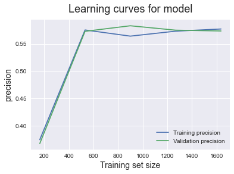

```
without_reg
```

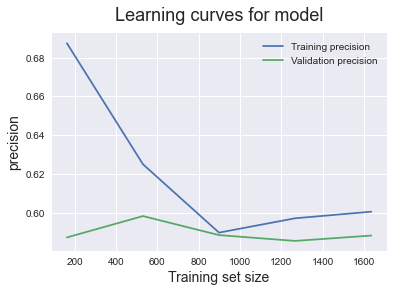

```python
for k,v in best_models.items():
    print(k)
    plot_learning_curves(v, train_X, train_y)
    v.fit(train_X, train_y)
    print()
```

```python
log_best_cv = best_models["with_reg"]
```

### Test

```python
from sklearn.metrics import plot_confusion_matrix
```

```python
def fit_model_with_test(model, train_X, train_y, test_X, test_y):
    model.fit(train_X, train_y)
    predicted = model.predict(test_X)
    print(metrics.classification_report(test_y, predicted))
    disp = plot_confusion_matrix(model, test_X, test_y,
                                     cmap=plt.cm.Blues)
    print(disp.confusion_matrix)
    plt.grid(None)
    plt.show()
```

```
              precision    recall  f1-score   support

           0       0.52      0.38      0.44       276
           1       0.59      0.72      0.65       338

    accuracy                           0.57       614
   macro avg       0.55      0.55      0.54       614
weighted avg       0.56      0.57      0.55       614

[[104 172]
 [ 95 243]]
```

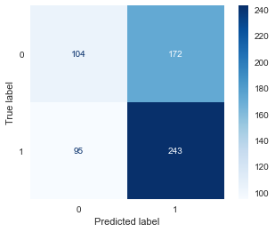

```python
fit_model_with_test(poly_best_cv, train_X, train_y, test_X, test_y)
```

## KNN

### 1. Baseline

```python
from sklearn.neighbors import KNeighborsClassifier
```

```python
baseline_knn = KNeighborsClassifier()
cross_validation(baseline_knn, numeric_train, train_y)
```

```
fit_time: 0.01 (+/- 0.00)
score_time: 0.04 (+/- 0.00)
test_accuracy: 0.50 (+/- 0.02)
test_precision: 0.54 (+/- 0.01)
test_recall: 0.59 (+/- 0.05)
test_f1: 0.56 (+/- 0.03)
```

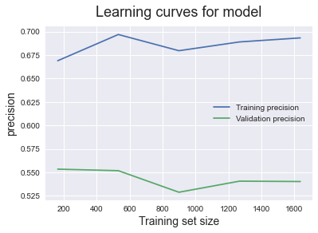

```python
plot_learning_curves(baseline_knn, numeric_train, train_y)
```

También se probó con RobustScaler.

### 2. Atributos numéricos + Standarize + New attribute

```python
knn_grid_values = {'classifier__n_neighbors':[1,3, 6, 9, 11],
                   'classifier__weights':['uniform', 'distance']}


knn_num_best_cv = define_pipeline_and_optimize(categorical_pipeline='remove',
                                            binary_pipeline='remove',
                                            model_grid_values=knn_grid_values,
                                            custom_grid_values={},
                                            model=KNeighborsClassifier())
```

```
{'classifier__n_neighbors': 9, 'classifier__weights': 'distance'}
accuracy: 0.54
precision: 0.57
recall: 0.65
f1: 0.61
```

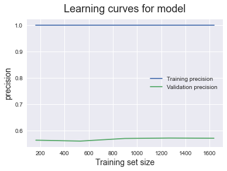

```python
plot_learning_curves(knn_num_best_cv, train_X, train_y)
```

### 3. Atributos numéricos + categóricos One Hot Encoding + Standarize

```python
all_features_knn = define_pipeline(model=KNeighborsClassifier(),
                           artist_feature=False)

cross_validation(all_features_knn, train_X, train_y)
```

```
fit_time: 0.12 (+/- 0.01)
score_time: 0.11 (+/- 0.00)
test_accuracy: 0.55 (+/- 0.03)
test_precision: 0.58 (+/- 0.02)
test_recall: 0.66 (+/- 0.02)
test_f1: 0.62 (+/- 0.02)
```

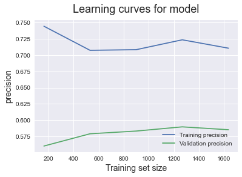

```python
plot_learning_curves(all_features_knn, train_X, train_y)
```

### 4. Gridsearch Atributos numéricos + categóricos One Hot Encoding + Standarize + new atribute

```python
knn_best_cv = define_pipeline_and_optimize(model_grid_values=knn_grid_values,
                                            model=KNeighborsClassifier())
```

```
{'classifier__n_neighbors': 6, 'classifier__weights': 'uniform'}
accuracy: 0.54
precision: 0.60
recall: 0.51
f1: 0.55
```

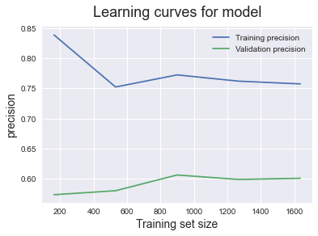

```python
plot_learning_curves(knn_best_cv, train_X, train_y)
```

### Test

```
              precision    recall  f1-score   support

           0       0.53      0.41      0.46       276
           1       0.59      0.70      0.64       338

    accuracy                           0.57       614
   macro avg       0.56      0.55      0.55       614
weighted avg       0.56      0.57      0.56       614

[[114 162]
 [103 235]]
```

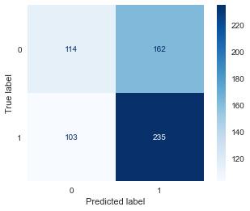

```python
fit_model_with_test(all_features_knn, train_X, train_y, test_X, test_y)
```

## SVM

### 1. Baseline

Se prueban los modelos escogidos solo con datos numéricos para tener un baseline con el que comparar resultados más tarde.

```python
from sklearn.svm import SVC
```

```python
baseline_svm = SVC(random_state=42, kernel='linear')
cross_validation(baseline_svm, numeric_train, train_y)
```

```
fit_time: 32.45 (+/- 10.40)
score_time: 0.02 (+/- 0.01)
test_accuracy: 0.55 (+/- 0.00)
test_precision: 0.55 (+/- 0.00)
test_recall: 1.00 (+/- 0.00)
test_f1: 0.71 (+/- 0.00)
```

También se probó con RobustScaler.

### 2. Atributos numéricos + categóricos One Hot Encoding + Standarize

```python
# create pipeline to one hot encode the categories
all_features_svm = define_pipeline(model=SVC(random_state=42, kernel='linear'),
                           artist_feature=False)

cross_validation(all_features_svm, train_X, train_y)
```

```
fit_time: 0.68 (+/- 0.08)
score_time: 0.12 (+/- 0.03)
test_accuracy: 0.58 (+/- 0.03)
test_precision: 0.59 (+/- 0.02)
test_recall: 0.79 (+/- 0.04)
test_f1: 0.68 (+/- 0.03)
```

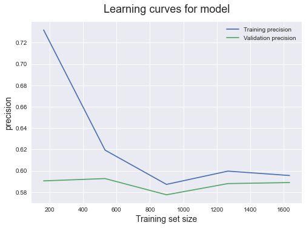

```python
plot_learning_curves(all_features_svm, train_X, train_y)
```

### 3. Gridsearch Atributos numéricos + categóricos One Hot Encoding + Standarize + new atribute

```python
svm_grid_values = {
         'classifier__kernel': ['poly','rbf'],
         'classifier__C': [0.1, 1, 10, 100, 1000],
         'classifier__gamma': [1, 0.1, 0.01, 0.001, 0.0001],
        }

svm_best_cv = define_pipeline_and_optimize( model_grid_values=svm_grid_values,
                                            custom_grid_values={},
                                            model=SVC(random_state=42))
```

```
{'classifier__C': 1000, 'classifier__gamma': 0.01, 'classifier__kernel': 'rbf'}
accuracy: 0.57
precision: 0.60
recall: 0.65
f1: 0.62
```

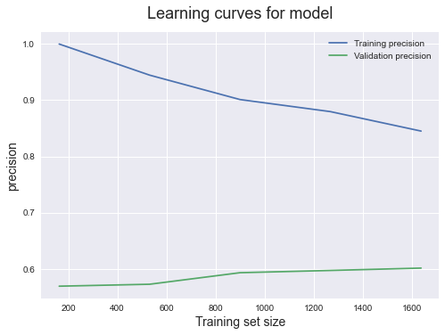

```python
plot_learning_curves(svm_best_cv, train_X, train_y)
```

### Test

```
              precision    recall  f1-score   support

           0       0.54      0.26      0.36       276
           1       0.58      0.82      0.68       338

    accuracy                           0.57       614
   macro avg       0.56      0.54      0.52       614
weighted avg       0.56      0.57      0.53       614

[[ 73 203]
 [ 62 276]]
```

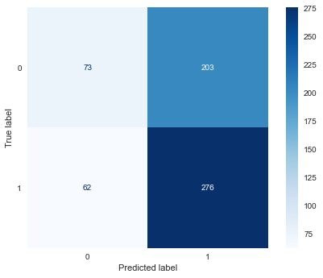

```python
fit_model_with_test(all_features_svm, train_X, train_y, test_X, test_y)
```

## Random Forest

### 1. Baseline

```python
baseline_rf = RandomForestClassifier(n_estimators=100, max_depth=2,
                                     random_state=42, n_jobs=-1)
cross_validation(baseline_rf, numeric_train, train_y)
```

```
fit_time: 0.27 (+/- 0.03)
score_time: 0.12 (+/- 0.01)
test_accuracy: 0.55 (+/- 0.01)
test_precision: 0.55 (+/- 0.00)
test_recall: 0.98 (+/- 0.02)
test_f1: 0.71 (+/- 0.01)
```

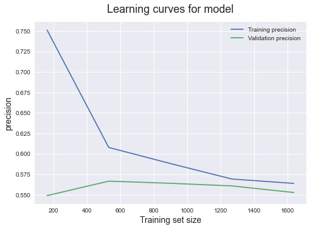

```python
plot_learning_curves(baseline_rf, numeric_train, train_y)
```

### 2. Atributos numéricos + Label Encoding

```python
class MultiColumnLabelEncoder(BaseEstimator, TransformerMixin):

    def __init__(self):
        self.mappings = {}

    def fit(self,X,y=None):
        for col in X.columns:
            col_dictionary = {}
            original_strings = X[col].value_counts().index
            numbers = X[col].astype('category').cat.codes.value_counts().index
            col_dictionary = dict(zip(original_strings, numbers))
            self.mappings[col] = col_dictionary
        return self

    def transform(self,X):
        X = X.copy()

        for col in X.columns:
            mapping_dict = self.mappings[col]

            strings_not_found = X[~X[col].isin(mapping_dict.keys())].index

            # map found values
            X.replace({col: mapping_dict}, inplace=True)

            # put most frequent value for not found strings
            keys_view = mapping_dict.keys()
            key_iterator = iter(keys_view)
            first_key = next(key_iterator)
            X.loc[strings_not_found, col] = first_key
        return X
```

```python
# create pipeline
categorical_transformer = Pipeline([
        ("label_encoder", MultiColumnLabelEncoder()) ])

all_features_rf = define_pipeline(categorical_pipeline=categorical_transformer,
                           numerical_pipeline=None,
                           model=RandomForestClassifier(n_estimators=100, random_state=42, n_jobs=-1),
                           artist_feature=False)

cross_validation(all_features_rf, train_X, train_y)
```

```
fit_time: 0.40 (+/- 0.03)
score_time: 0.52 (+/- 0.56)
test_accuracy: 0.57 (+/- 0.02)
test_precision: 0.60 (+/- 0.02)
test_recall: 0.70 (+/- 0.03)
test_f1: 0.64 (+/- 0.02)
```

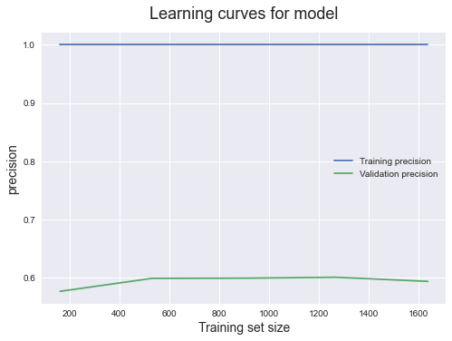

```python
plot_learning_curves(all_features_rf, train_X, train_y)
```

### 3. Atributos numéricos + Label Encoding + new feature

```python
rf_grid_values =  grid_values = {
         'classifier__n_estimators': [10, 50, 100, 300],
         'classifier__max_features': ["sqrt", 0.1, 0.3, 0.6],
         'classifier__min_samples_leaf': [1, 5, 15],
         'classifier__max_depth':[6, 9, 13]
        }

rf_best_cv = define_pipeline_and_optimize(categorical_pipeline=categorical_transformer,
                                            numerical_pipeline=None,
                                            model_grid_values=rf_grid_values,
                                            custom_grid_values={},
                                            model=RandomForestClassifier(random_state=42, n_jobs=-1))
```

```
{'classifier__max_depth': 13, 'classifier__max_features': 0.6, 'classifier__min_samples_leaf': 15, 'classifier__n_estimators': 50}
accuracy: 0.60
precision: 0.60
recall: 0.77
f1: 0.68
```

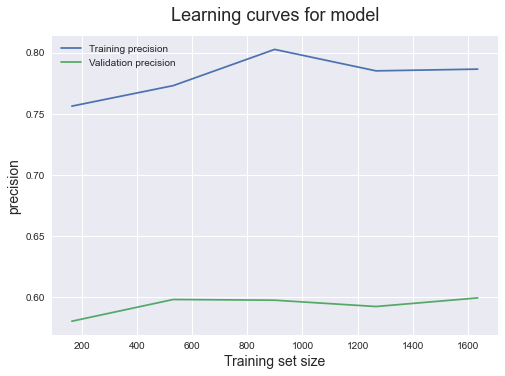

```python
plot_learning_curves(rf_best_cv, train_X, train_y)
```

### 4. Atributos numéricos + One Hot Encoding + new feature

```python
rf_best_oh_cv = define_pipeline_and_optimize(numerical_pipeline=None,
                                            model_grid_values=rf_grid_values,
                                            custom_grid_values={},
                                            model=RandomForestClassifier(random_state=42, n_jobs=-1))
```

```
{'classifier__max_depth': 13, 'classifier__max_features': 0.3, 'classifier__min_samples_leaf': 5, 'classifier__n_estimators': 50}
accuracy: 0.59
precision: 0.60
recall: 0.76
f1: 0.67
```

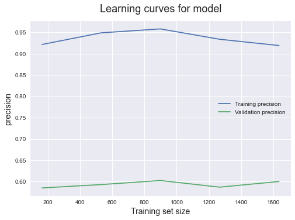

```python
plot_learning_curves(rf_best_oh_cv, train_X, train_y)
```

### Test

```
              precision    recall  f1-score   support

           0       0.52      0.37      0.43       276
           1       0.58      0.72      0.64       338

    accuracy                           0.56       614
   macro avg       0.55      0.54      0.54       614
weighted avg       0.55      0.56      0.55       614

[[103 173]
 [ 96 242]]
```

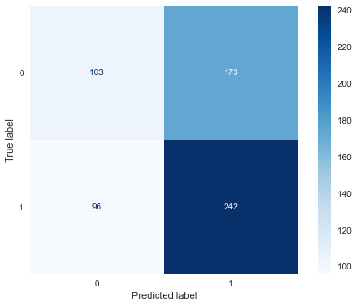

```python
fit_model_with_test(rf_best_cv, train_X, train_y, test_X, test_y)
```

## Importancia atributos

Se tienen que realizar algunas operaciones para obtener los nombres de los atributos resultantes después de aplicar el *pipeline* correspondiente.

```python
knn_classifier = all_features_knn['classifier']
```

```python
preprocessor = all_features_knn['preprocess']
preprocessor
```

```
Pipeline(steps=[('add_feature_previous_popular',
                 ArtistHasPreviousPopular(add=False,
                                          binary_features=['is_collab',
                                                           'explicit', 'is_ost',
                                                           'for_reality_tvshow'])),
                ('preprocessor',
                 ColumnTransformer(transformers=[('num',
                                                  Pipeline(steps=[('scaler',
                                                                   StandardScaler())]),
                                                  ['acousticness',
                                                   'danceability',
                                                   'duration_ms', 'energy',
                                                   'first_time_in_chart_month',
                                                   'first_time...art_year',
                                                   'instrumentalness',
                                                   'liveness', 'loudness',
                                                   'speechiness', 'tempo',
                                                   'valence']),
                                                 ('binary',
                                                  Pipeline(steps=[('pass',
                                                                   PassThrough())]),
                                                  ['is_collab', 'explicit',
                                                   'is_ost',
                                                   'for_reality_tvshow']),
                                                 ('cat',
                                                  Pipeline(steps=[('one_hot_encoder',
                                                                   OneHotEncoder(handle_unknown='ignore'))]),
                                                  ['producer', 'distributor',
                                                   'album_type',
                                                   'first_time_in_chart_period'])]))])
```

```python
one_hot_encoder = all_features_knn['preprocess']['preprocessor'].transformers[-1][1].steps[-1][-1]
one_hot_encoder
```

```
OneHotEncoder(handle_unknown='ignore')
```

```python
one_hot_encoder.fit(train_X[categorical_features])
```

```
OneHotEncoder(handle_unknown='ignore')
```

```python
import itertools
```

```python
train_X[categorical_features].head(1)
```

|  | producer | distributor | album_type | first_time_in_chart_period |
| --- | --- | --- | --- | --- |
| 0 | sm entertainment | other | album | holiday |

```python
print(one_hot_encoder.transform(train_X[categorical_features])[0])
```

```
  (0, 2)	1.0
  (0, 5)	1.0
  (0, 9)	1.0
  (0, 12)	1.0
```

```python
one_hot_labels = list(itertools.chain(*[list(x) for x in one_hot_encoder.categories_]))
one_hot_labels
```

```
['jyp entertainment',
 'other',
 'sm entertainment',
 'stone music entertainment',
 'yg entertainment',
 'other',
 'stone music entertainment',
 '지니뮤직',
 '카카오 m',
 'album',
 'compilation',
 'single',
 'holiday',
 'other',
 'summer']
```

```python
all_features = numeric_features + binary_features + one_hot_labels
len(all_features)
```

```
31
```

```python
train_X_final = preprocessor.fit_transform(train_X, train_y)
test_X_final = preprocessor.transform(test_X)
```

```python
train_X_final.shape
```

```
(2455, 31)
```

```python
import eli5
from eli5.sklearn import PermutationImportance
```

```python
knn = knn_classifier.fit(train_X_final, train_y)
perm = PermutationImportance(knn, scoring='precision').fit(test_X_final, test_y)
```

```python
# No se muestra el color de cada peso, ya que al guardarlo se pierde. Los colores se pueden ver en la documentación.
eli5.show_weights(perm, feature_names=all_features, top=100)
```

| Weight | Feature |
| --- | --- |
| 0.0315 ± 0.0275 | danceability |
| 0.0239 ± 0.0113 | loudness |
| 0.0238 ± 0.0327 | first_time_in_chart_year |
| 0.0226 ± 0.0157 | acousticness |
| 0.0191 ± 0.0244 | tempo |
| 0.0162 ± 0.0176 | valence |
| 0.0145 ± 0.0155 | liveness |
| 0.0138 ± 0.0204 | first_time_in_chart_month |
| 0.0136 ± 0.0060 | album |
| 0.0116 ± 0.0071 | stone music entertainment |
| 0.0104 ± 0.0090 | 카카오 m |
| 0.0103 ± 0.0050 | sm entertainment |
| 0.0098 ± 0.0051 | 지니뮤직 |
| 0.0097 ± 0.0082 | is_collab |
| 0.0096 ± 0.0053 | other |
| 0.0083 ± 0.0059 | is_ost |
| 0.0080 ± 0.0086 | other |
| 0.0074 ± 0.0185 | energy |
| 0.0074 ± 0.0108 | single |
| 0.0070 ± 0.0148 | speechiness |
| 0.0046 ± 0.0141 | duration_ms |
| 0.0039 ± 0.0119 | summer |
| 0.0036 ± 0.0076 | other |
| 0.0035 ± 0.0135 | holiday |
| 0.0034 ± 0.0029 | for_reality_tvshow |
| 0.0018 ± 0.0012 | stone music entertainment |
| 0.0015 ± 0.0000 | explicit |
| 0.0011 ± 0.0016 | compilation |
| -0.0005 ± 0.0052 | instrumentalness |
| -0.0007 ± 0.0023 | yg entertainment |
| -0.0012 ± 0.0012 | jyp entertainment |